# Pengantar ke ML

Erlangga Sri Heryanto - G1401231075

# Import Dependencies

```r
library(MASS)
library(naniar)
library(lubridate)
library(tidyverse)
library(mice)
show_unique <- function(data, col) {
  cat("\nUnique values of", col, ":\n")
  print(unique(data[[col]]))
}

investigasi_mar <- function(data, col_target, alpha=0.05) {
  # Buat indikator target (TRUE jika hilang, FALSE jika ada)
  target_is_missing <- is.na(data[[col_target]])

  # Cek apakah target punya missing value? Kalau tidak, stop.
  if (sum(target_is_missing) == 0) {
    stop("Kolom target tidak memiliki missing value!")
  }

  print(paste("=== Investigasi MAR untuk", col_target, "==="))

  # Ambil semua kolom lain
  fitur_lain <- setdiff(names(data), col_target)

  for (f in fitur_lain) {

    # --- HUBUNGAN NILAI (VALUE) ---
    if (is.numeric(data[[f]])) {
      try({
        test_val <- t.test(data[[f]] ~ target_is_missing)
        if (test_val$p.value < alpha) {
          print(paste("[VALUE] Numerik:", f, "mempengaruhi hilangnya", col_target, "(p =", format.pval(test_val$p.value), ")"))
        }
      }, silent = TRUE)

    } else {
      try({
        test_val <- chisq.test(table(data[[f]], target_is_missing))
        if (test_val$p.value < alpha) {
          print(paste("[VALUE] Kategori:", f, "mempengaruhi hilangnya", col_target, "(p =", format.pval(test_val$p.value), ")"))
        }
      }, silent = TRUE)
    }

    # --- HUBUNGAN POLA (PATTERN) ---
    if (any(is.na(data[[f]]))) {
      f_is_missing <- is.na(data[[f]])
      try({
        test_pat <- chisq.test(table(f_is_missing, target_is_missing))
        if (test_pat$p.value < alpha) {
          print(paste("[PATTERN] Pola hilang:", f, "berkaitan dengan hilangnya", col_target, "(p =", format.pval(test_pat$p.value), ")"))
        }
      }, silent = TRUE)
    }
  }
}
```

# Membaca Data

```r
data.cafe <- read.csv("Cafe Sales.csv", header = TRUE)
head(data.cafe)
```

```
##   Transaction.ID     Item Quantity Price.Per.Unit Total.Spent Payment.Method
## 1    TXN_1961373   Coffee        2            2.0         4.0    Credit Card
## 2    TXN_4977031     Cake        4            3.0        12.0           Cash
## 3    TXN_4271903   Cookie        4            1.0       ERROR    Credit Card
## 4    TXN_7034554    Salad        2            5.0        10.0        UNKNOWN
## 5    TXN_3160411   Coffee        2            2.0         4.0 Digital Wallet
## 6    TXN_2602893 Smoothie        5            4.0        20.0    Credit Card
##   Location Transaction.Date
## 1 Takeaway       2023-09-08
## 2 In-store       2023-05-16
## 3 In-store       2023-07-19
## 4  UNKNOWN       2023-04-27
## 5 In-store       2023-06-11
## 6                2023-03-31
```

```r
# Struktur data
str(data.cafe)
```

```
## 'data.frame':    10000 obs. of  8 variables:
##  $ Transaction.ID  : chr  "TXN_1961373" "TXN_4977031" "TXN_4271903" "TXN_7034554" ...
##  $ Item            : chr  "Coffee" "Cake" "Cookie" "Salad" ...
##  $ Quantity        : chr  "2" "4" "4" "2" ...
##  $ Price.Per.Unit  : chr  "2.0" "3.0" "1.0" "5.0" ...
##  $ Total.Spent     : chr  "4.0" "12.0" "ERROR" "10.0" ...
##  $ Payment.Method  : chr  "Credit Card" "Cash" "Credit Card" "UNKNOWN" ...
##  $ Location        : chr  "Takeaway" "In-store" "In-store" "UNKNOWN" ...
##  $ Transaction.Date: chr  "2023-09-08" "2023-05-16" "2023-07-19" "2023-04-27" ...
```

# Menyiapkan Data

Cek *unique value* dari setiap kolom.

```r
cols <- c(
  "Item",
  "Quantity",
  "Price.Per.Unit",
  "Total.Spent",
  "Payment.Method",
  "Location",
  "Transaction.Date"
)

purrr::walk(cols, show_unique, data = data.cafe)
```

```
##
## Unique values of Item :
##  [1] "Coffee"   "Cake"     "Cookie"   "Salad"    "Smoothie" "UNKNOWN"
##  [7] "Sandwich" ""         "ERROR"    "Juice"    "Tea"
##
## Unique values of Quantity :
## [1] "2"       "4"       "5"       "3"       "1"       "ERROR"   "UNKNOWN"
## [8] ""
##
## Unique values of Price.Per.Unit :
## [1] "2.0"     "3.0"     "1.0"     "5.0"     "4.0"     "1.5"     ""
## [8] "ERROR"   "UNKNOWN"
##
## Unique values of Total.Spent :
##  [1] "4.0"     "12.0"    "ERROR"   "10.0"    "20.0"    "9.0"     "16.0"
```

[output cut: 85 more lines]

```r
data.cafe <- data.cafe %>%
  # Ganti semua error menjadi NA di semua kolom
  mutate(across(everything(),
                ~ replace(., . %in% c("ERROR", "UNKNOWN", ""), NA))) %>%

  # Ubah tipe datanya
  mutate(
    # Ubah ke Integer
    Quantity = as.integer(Quantity),

    Price.Per.Unit = as.numeric(Price.Per.Unit),
    Total.Spent = as.numeric(Total.Spent),

    Transaction.Date = ymd(Transaction.Date),

    Item = as.factor(Item),
    Payment.Method = as.factor(Payment.Method),
    Location = as.factor(Location),

    Transaction.ID = as.character(Transaction.ID)
  )

head(data.cafe)
```

```
##   Transaction.ID     Item Quantity Price.Per.Unit Total.Spent Payment.Method
## 1    TXN_1961373   Coffee        2              2           4    Credit Card
## 2    TXN_4977031     Cake        4              3          12           Cash
## 3    TXN_4271903   Cookie        4              1          NA    Credit Card
## 4    TXN_7034554    Salad        2              5          10           <NA>
## 5    TXN_3160411   Coffee        2              2           4 Digital Wallet
## 6    TXN_2602893 Smoothie        5              4          20    Credit Card
##   Location Transaction.Date
## 1 Takeaway       2023-09-08
## 2 In-store       2023-05-16
## 3 In-store       2023-07-19
## 4     <NA>       2023-04-27
## 5 In-store       2023-06-11
## 6     <NA>       2023-03-31
```

```r
# Struktur data
str(data.cafe)
```

```
## 'data.frame':    10000 obs. of  8 variables:
##  $ Transaction.ID  : chr  "TXN_1961373" "TXN_4977031" "TXN_4271903" "TXN_7034554" ...
##  $ Item            : Factor w/ 8 levels "Cake","Coffee",..: 2 1 3 5 2 7 NA 6 NA 6 ...
##  $ Quantity        : int  2 4 4 2 2 5 3 4 5 5 ...
##  $ Price.Per.Unit  : num  2 3 1 5 2 4 3 4 3 4 ...
##  $ Total.Spent     : num  4 12 NA 10 4 20 9 16 15 20 ...
##  $ Payment.Method  : Factor w/ 3 levels "Cash","Credit Card",..: 2 1 2 NA 3 2 NA 1 NA NA ...
##  $ Location        : Factor w/ 2 levels "In-store","Takeaway": 2 1 1 NA 1 NA 2 NA 2 1 ...
##  $ Transaction.Date: Date, format: "2023-09-08" "2023-05-16" ...
```

```r
# Ringkasan data
summary(data.cafe)
```

```
##  Transaction.ID           Item         Quantity     Price.Per.Unit
##  Length:10000       Juice   :1171   Min.   :1.000   Min.   :1.00
##  Class :character   Coffee  :1165   1st Qu.:2.000   1st Qu.:2.00
##  Mode  :character   Salad   :1148   Median :3.000   Median :3.00
##                     Cake    :1139   Mean   :3.029   Mean   :2.95
##                     Sandwich:1131   3rd Qu.:4.000   3rd Qu.:4.00
##                     (Other) :3277   Max.   :5.000   Max.   :5.00
##                     NA's    : 969   NA's   :479     NA's   :533
##   Total.Spent            Payment.Method     Location    Transaction.Date
##  Min.   : 1.000   Cash          :2258   In-store:3017   Min.   :2023-01-01
##  1st Qu.: 4.000   Credit Card   :2273   Takeaway:3022   1st Qu.:2023-04-01
##  Median : 8.000   Digital Wallet:2291   NA's    :3961   Median :2023-07-02
##  Mean   : 8.924   NA's          :3178                   Mean   :2023-07-01
##  3rd Qu.:12.000                                         3rd Qu.:2023-10-02
##  Max.   :25.000                                         Max.   :2023-12-31
##  NA's   :502                                            NA's   :460
```

# Pengecekkan Data Hilang

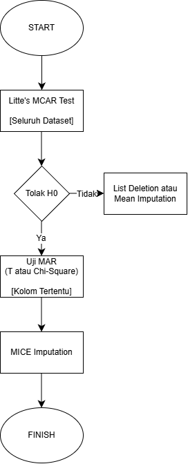

```r
miss_var_summary(data.cafe)
```

```
## # A tibble: 8 × 3
##   variable         n_miss pct_miss
##   <chr>             <int>    <num>
## 1 Location           3961    39.6
## 2 Payment.Method     3178    31.8
## 3 Item                969     9.69
## 4 Price.Per.Unit      533     5.33
## 5 Total.Spent         502     5.02
## 6 Quantity            479     4.79
## 7 Transaction.Date    460     4.6
## 8 Transaction.ID        0     0
```

Berdasarkan hasil `miss_var_summary(data.cafe)` di atas, dapat diidentifikasi sebaran data hilang sebagai berikut:

- `Location` dan `Payment.Method` memiliki jumlah data hilang yang sangat masif, masing-masing sebesar 39.6% (3.961 baris) dan 31.8% (3.178 baris).
- `Item` memiliki data hilang sebesar 9.69%.
- `Price.Per.Unit`, `Total.Spent`, `Quantity`, dan `Transaction.Date` memiliki tingkat kehilangan data yang relatif rendah dan seragam, berkisar antara 4.6% hingga 5.3%. Sepertinya ini adalah baris-baris yang awalnya berisi teks “ERROR” atau “UNKNOWN”.

## MCAR

```r
mcar_test(data.cafe)
```

```
## # A tibble: 1 × 4
##   statistic    df p.value missing.patterns
##       <dbl> <dbl>   <dbl>            <int>
## 1      422.   395   0.165               78
```

Untuk memvalidasi mekanisme kehilangan data, dilakukan uji *Little’s MCAR Test* dengan hipotesis sebagai berikut:

- $H_0$: Data hilang bersifat *Missing Completely at Random* (MCAR).
- $H_1$: Data hilang tidak bersifat MCAR.

Karena *p-value* > 0.05, maka **Gagal Tolak $H_0$**. Dengan tingkat kepercayaan 95%, belum cukup bukti untuk menyatakan bahwa pola kehilangan data bersifat sistematis. Dengan kata lain, data yang hilang pada dataset ini diasumsikan bersifat MCAR.

Jika ingin mempelajari *Little’s MCAR Test* lebih lanjut.

[A Test of Missing Completely at Random for Multivariate Data with Missing Values](https://doi.org/10.2307/2290157)

## MAR

```r
# Misalnya kita fokus ke kolom Location
investigasi_mar(data.cafe[, -c(1)], "Location")
```

```
## [1] "=== Investigasi MAR untuk Location ==="
## [1] "[VALUE] Kategori: Item mempengaruhi hilangnya Location (p = 0.0032038 )"
```

Meskipun uji Little menunjukkan data bersifat MCAR secara global, dilakukan pemeriksaan lebih spesifik untuk memastikan hubungan antara hilangnya data `Location` dengan peubah lainnya. Hasil investigasi spesifik menunjukkan hilangnya data `Location` memiliki hubungan signifikan ($p < 0.05$) dengan peubah `Item`, yang mengindikasikan adanya mekanisme *Missing at Random* (MAR) pada peubah tersebut.

# Penanganan Data Hilang dengan Teknik Sederhana

## Penghapusan Kasus (Listwise or Case Deletion)

Gunakan code berikut ini kalau memang data hilang ditemukan memiliki mekanisme MCAR saja.

```r
data.hilang <- data.cafe[!complete.cases(data.cafe), ]
head(data.hilang)
```

```
##   Transaction.ID     Item Quantity Price.Per.Unit Total.Spent Payment.Method
## 3    TXN_4271903   Cookie        4              1          NA    Credit Card
## 4    TXN_7034554    Salad        2              5          10           <NA>
## 6    TXN_2602893 Smoothie        5              4          20    Credit Card
## 7    TXN_4433211     <NA>        3              3           9           <NA>
## 8    TXN_6699534 Sandwich        4              4          16           Cash
## 9    TXN_4717867     <NA>        5              3          15           <NA>
##   Location Transaction.Date
## 3 In-store       2023-07-19
## 4     <NA>       2023-04-27
## 6     <NA>       2023-03-31
## 7 Takeaway       2023-10-06
## 8     <NA>       2023-10-28
## 9 Takeaway       2023-07-28
```

```r
data.lengkap1 <- na.omit(data.cafe)
head(data.lengkap1)
```

```
##    Transaction.ID     Item Quantity Price.Per.Unit Total.Spent Payment.Method
## 1     TXN_1961373   Coffee        2              2           4    Credit Card
## 2     TXN_4977031     Cake        4              3          12           Cash
## 5     TXN_3160411   Coffee        2              2           4 Digital Wallet
## 11    TXN_2548360    Salad        5              5          25           Cash
## 13    TXN_7619095 Sandwich        2              4           8           Cash
## 16    TXN_2847255    Salad        3              5          15    Credit Card
##    Location Transaction.Date
## 1  Takeaway       2023-09-08
## 2  In-store       2023-05-16
## 5  In-store       2023-06-11
## 11 Takeaway       2023-11-07
## 13 In-store       2023-05-03
## 16 In-store       2023-11-15
```

Gunakan code berikut ini kalau memang data hilang ditemukan memiliki mekanisme MCAR atau MAR.

```r
rataan.qty <- median(data.cafe$Quantity, na.rm = TRUE)
rataan.qty
```

```
## [1] 3
```

```r
data.lengkap2 <- data.cafe
data.lengkap2$Quantity <- ifelse(is.na(data.lengkap2$Quantity), rataan.qty, data.lengkap2$Quantity)
head(data.lengkap2)
```

```
##   Transaction.ID     Item Quantity Price.Per.Unit Total.Spent Payment.Method
## 1    TXN_1961373   Coffee        2              2           4    Credit Card
## 2    TXN_4977031     Cake        4              3          12           Cash
## 3    TXN_4271903   Cookie        4              1          NA    Credit Card
## 4    TXN_7034554    Salad        2              5          10           <NA>
## 5    TXN_3160411   Coffee        2              2           4 Digital Wallet
## 6    TXN_2602893 Smoothie        5              4          20    Credit Card
##   Location Transaction.Date
## 1 Takeaway       2023-09-08
## 2 In-store       2023-05-16
## 3 In-store       2023-07-19
## 4     <NA>       2023-04-27
## 5 In-store       2023-06-11
## 6     <NA>       2023-03-31
```

## Pengisian dengan MICE (MICE *Imputation*)

Disarankan menggunakan code berikut ini saat ditemukan mekanisme data hilang MAR.

```r
data.lengkap3 <- data.cafe
data.lengkap3$Transaction.Date <- as.numeric(data.lengkap3$Transaction.Date)
head(data.lengkap3)
```

```
##   Transaction.ID     Item Quantity Price.Per.Unit Total.Spent Payment.Method
## 1    TXN_1961373   Coffee        2              2           4    Credit Card
## 2    TXN_4977031     Cake        4              3          12           Cash
## 3    TXN_4271903   Cookie        4              1          NA    Credit Card
## 4    TXN_7034554    Salad        2              5          10           <NA>
## 5    TXN_3160411   Coffee        2              2           4 Digital Wallet
## 6    TXN_2602893 Smoothie        5              4          20    Credit Card
##   Location Transaction.Date
## 1 Takeaway            19608
## 2 In-store            19493
## 3 In-store            19557
## 4     <NA>            19474
## 5 In-store            19519
## 6     <NA>            19447
```

Sebelum melakukan proses imputasi, dilakukan pra-pemrosesan pada peubah `Transaction.Date`. Peubah ini dikonversi sementara dari format tanggal (*Date*) menjadi format numerik untuk memungkinkan algoritma MICE melakukan perhitungan matematis (regresi) pada data waktu tersebut.

```r
mice_method.cafe <- mice(data.lengkap3, maxit = 0)$method # maxit = 0 artinya jangan dihitung dulu
print(mice_method.cafe)
```

```
##   Transaction.ID             Item         Quantity   Price.Per.Unit
##               ""        "polyreg"            "pmm"            "pmm"
##      Total.Spent   Payment.Method         Location Transaction.Date
##            "pmm"        "polyreg"         "logreg"            "pmm"
```

Selanjutnya, dilakukan proses inisialisasi (*dry run*) dengan parameter `maxit = 0`. Langkah ini bertujuan untuk mengevaluasi metode imputasi yang dipilih secara otomatis oleh algoritma MICE berdasarkan tipe data masing-masing peubah, tanpa melakukan iterasi perhitungan.

Berdasarkan hasil dry run di atas, berikut adalah spesifikasi metode yang akan digunakan:

1. Peubah Numerik (`Quantity`, `Price.Per.Unit`, `Total.Spent`, `Transaction.Date`) *Predictive Mean Matching* (`pmm`) ini dipilih karena peubah bertipe numerik/kontinu. PMM sangat robust karena mengisi missing value dengan mengambil nilai asli dari observasi lain yang memiliki kemiripan (donor), sehingga menjamin hasil imputasi tetap masuk akal (misalnya, tidak akan menghasilkan nilai negatif atau desimal yang tidak realistis).
2. Peubah Kategorik Nominal > 2 Level (`Item`, `Payment.Method`) Peubah ini memiliki lebih dari dua kategori yang tidak berjenjang (*multiclass*). *Polytomous Regression* (`polyreg`) ini menggunakan regresi multinomial untuk memprediksi probabilitas setiap kategori.
3. Peubah Kategorik Biner (`Location`) Peubah ini terdeteksi hanya memiliki dua kategori. *Logistic Regression* (`logreg`) adalah standar terbaik untuk imputasi data biner.
4. Peubah Identifier (`Transaction.ID`) Algoritma secara otomatis mendeteksi bahwa kolom ini adalah *unique identifier* (ID) yang tidak memiliki nilai prediktif, sehingga dikeluarkan dari model imputasi untuk menjaga efisiensi.

```r
hasil_imputasi <- mice(data.lengkap3, method = mice_method.cafe, m = 5, seed = 75) # m = 5 artinya kita membuat 5 versi data
data.lengkap3 <- complete(hasil_imputasi, 1) # ambil hasil imputasi ke-1

data.lengkap3$Transaction.Date <- as.Date(data.lengkap3$Transaction.Date,
                                          origin = "1970-01-01")

head(data.lengkap3)
```

```
##   Transaction.ID     Item Quantity Price.Per.Unit Total.Spent Payment.Method
## 1    TXN_1961373   Coffee        2              2           4    Credit Card
## 2    TXN_4977031     Cake        4              3          12           Cash
## 3    TXN_4271903   Cookie        4              1           6    Credit Card
## 4    TXN_7034554    Salad        2              5          10           Cash
## 5    TXN_3160411   Coffee        2              2           4 Digital Wallet
## 6    TXN_2602893 Smoothie        5              4          20    Credit Card
##   Location Transaction.Date
## 1 Takeaway       2023-09-08
## 2 In-store       2023-05-16
## 3 In-store       2023-07-19
## 4 In-store       2023-04-27
## 5 In-store       2023-06-11
## 6 In-store       2023-03-31
```

Jika ingin mempelajari MICE *Imputation* lebih lanjut.

```r
citation("mice")
```

```
##
##   Stef van Buuren, Karin Groothuis-Oudshoorn (2011). mice: Multivariate
##   Imputation by Chained Equations in R. Journal of Statistical
##   Software, 45(3), 1-67. DOI 10.18637/jss.v045.i03.
##
## A BibTeX entry for LaTeX users is
##
##   @Article{,
##     title = {{mice}: Multivariate Imputation by Chained Equations in R},
##     author = {Stef {van Buuren} and Karin Groothuis-Oudshoorn},
##     journal = {Journal of Statistical Software},
##     year = {2011},
##     volume = {45},
##     number = {3},
##     pages = {1-67},
##     doi = {10.18637/jss.v045.i03},
##   }
```

# Pengecekkan Pencilan (*Outlier*)

```r
data.rumah <- read.csv("House Prices.csv", header = TRUE)
head(data.rumah)
```

```
##   Id MSSubClass MSZoning LotFrontage LotArea Street Alley LotShape LandContour
## 1  1         60       RL          65    8450   Pave  <NA>      Reg         Lvl
## 2  2         20       RL          80    9600   Pave  <NA>      Reg         Lvl
## 3  3         60       RL          68   11250   Pave  <NA>      IR1         Lvl
## 4  4         70       RL          60    9550   Pave  <NA>      IR1         Lvl
## 5  5         60       RL          84   14260   Pave  <NA>      IR1         Lvl
## 6  6         50       RL          85   14115   Pave  <NA>      IR1         Lvl
##   Utilities LotConfig LandSlope Neighborhood Condition1 Condition2 BldgType
## 1    AllPub    Inside       Gtl      CollgCr       Norm       Norm     1Fam
## 2    AllPub       FR2       Gtl      Veenker      Feedr       Norm     1Fam
## 3    AllPub    Inside       Gtl      CollgCr       Norm       Norm     1Fam
## 4    AllPub    Corner       Gtl      Crawfor       Norm       Norm     1Fam
## 5    AllPub       FR2       Gtl      NoRidge       Norm       Norm     1Fam
## 6    AllPub    Inside       Gtl      Mitchel       Norm       Norm     1Fam
##   HouseStyle OverallQual OverallCond YearBuilt YearRemodAdd RoofStyle RoofMatl
```

[output cut: 69 more lines]

## Pencilan Univariat

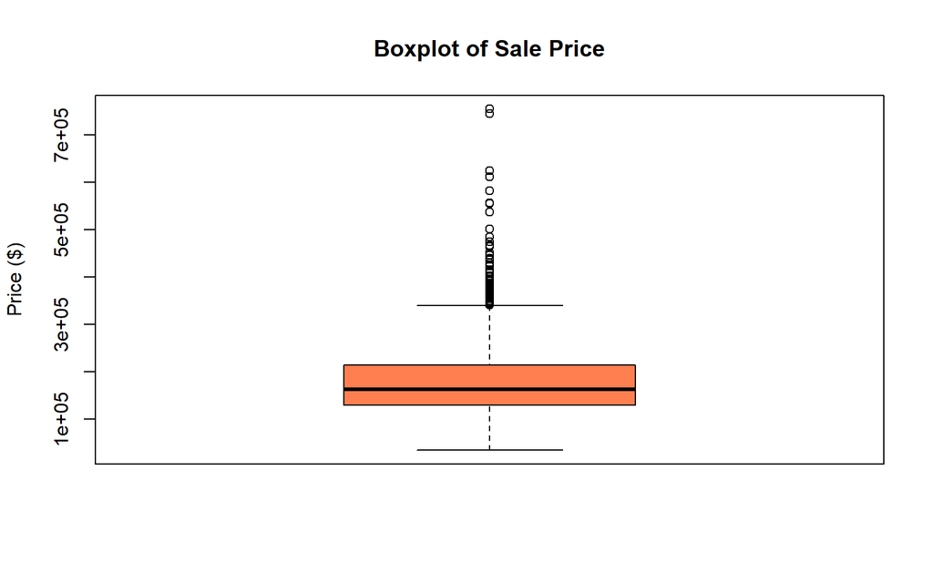

```r
boxplot(data.rumah$SalePrice,
        main = "Boxplot of Sale Price",
        ylab = "Price ($)",
        col = "coral")
```

Berdasarkan visualisasi menggunakan *Boxplot of Sale Price*, terlihat adanya sejumlah pengamatan yang terletak jauh di atas *whisker* bagian atas. Titik-titik lingkaran tersebut mengindikasikan adanya rumah dengan harga jual yang sangat tinggi dibandingkan mayoritas data dalam populasi tersebut.

```r
Q1.salePrice <- quantile(data.rumah$SalePrice, 0.25)
Q3.salePrice <- quantile(data.rumah$SalePrice, 0.75)
IQR.salePrice <- Q3.salePrice - Q1.salePrice

batas.bawah.salePrice <- Q1.salePrice - 1.5 * IQR.salePrice
batas.atas.salePrice <- Q3.salePrice + 1.5 * IQR.salePrice

print(paste("Batas Bawah Pencilan:", batas.bawah.salePrice))
```

```
## [1] "Batas Bawah Pencilan: 3937.5"
```

```r
print(paste("Batas Atas Pencilan:", batas.atas.salePrice))
```

```
## [1] "Batas Atas Pencilan: 340037.5"
```

```r
pencilan_univariat <- data.rumah$SalePrice[data.rumah$SalePrice < batas.bawah.salePrice | data.rumah$SalePrice > batas.atas.salePrice]
length(pencilan_univariat)
```

```
## [1] 61
```

Setelah dilakukan pemfilteran, teridentifikasi sebanyak 61 pencilan univariat pada peubah `SalePrice`.

## Pencilan dalam Regresi Linear

```r
model.rumah <- lm(SalePrice ~ GrLivArea, data = data.rumah)
summary(model.rumah)
```

```
##
## Call:
## lm(formula = SalePrice ~ GrLivArea, data = data.rumah)
##
## Residuals:
##     Min      1Q  Median      3Q     Max
## -462999  -29800   -1124   21957  339832
##
## Coefficients:
##              Estimate Std. Error t value Pr(>|t|)
## (Intercept) 18569.026   4480.755   4.144 3.61e-05 ***
## GrLivArea     107.130      2.794  38.348  < 2e-16 ***
## ---
## Signif. codes:  0 '***' 0.001 '**' 0.01 '*' 0.05 '.' 0.1 ' ' 1
##
## Residual standard error: 56070 on 1458 degrees of freedom
## Multiple R-squared:  0.5021, Adjusted R-squared:  0.5018
## F-statistic:  1471 on 1 and 1458 DF,  p-value: < 2.2e-16
```

Berdasarkan ringkasan model model.rumah, peubah `GrLivArea` memiliki pengaruh yang signifikan terhadap `SalePrice` ($p-value < 2 \times 10^{-16}$) dengan nilai koefisien determinasi ($R^2$) sebesar 0.5021. Hal ini menunjukkan bahwa sekitar 50.21% keragaman harga rumah dapat dijelaskan oleh luas area ruang tamu melalui model ini.

```r
res_student <- rstudent(model.rumah)
pencilan_regresi <- which(abs(res_student) > 3)
print(paste("Jumlah pencilan dalam regresi:", length(pencilan_regresi)))
```

```
## [1] "Jumlah pencilan dalam regresi: 27"
```

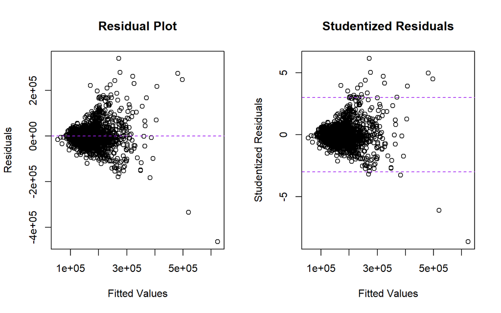

```r
par(mfrow = c(1, 2))

# Plot Sisaan (Residual Plot)
plot(predict(model.rumah), resid(model.rumah),
     main = "Residual Plot",
     xlab = "Fitted Values",
     ylab = "Residuals")
abline(h = 0, lty = 2, col = "purple")

# Plot Studentized Residual
plot(predict(model.rumah), res_student,
     main = "Studentized Residuals",
     xlab = "Fitted Values",
     ylab = "Studentized Residuals")
abline(h = c(-3, 3), lty = 2, col = "purple")
```

Untuk mendeteksi pengamatan yang tidak mampu dijelaskan dengan baik oleh model, dilakukan analisis sisaan (*residual analysis*):

- `*Residual Plot*`: Visualisasi menunjukkan beberapa titik yang menyimpang jauh dari garis horizontal nol, mengindikasikan adanya sisaan yang besar pada pengamatan tertentu.
- `*Studentized Residuals*`: Berdasarkan kriteria, pengamatan diidentifikasi sebagai pencilan jika nilai mutlak *studentized residual* lebih besar dari 3 ($|t_i| > 3$).
- Ditemukan sebanyak 27 pencilan dalam regresi yang berada di luar ambang batas $[-3, 3]$.

# Transformasi Data

```r
set.seed(75)
pendapatan <- rchisq(100, 3)
x <- pendapatan
```

Cek bentuk histogram dari data.

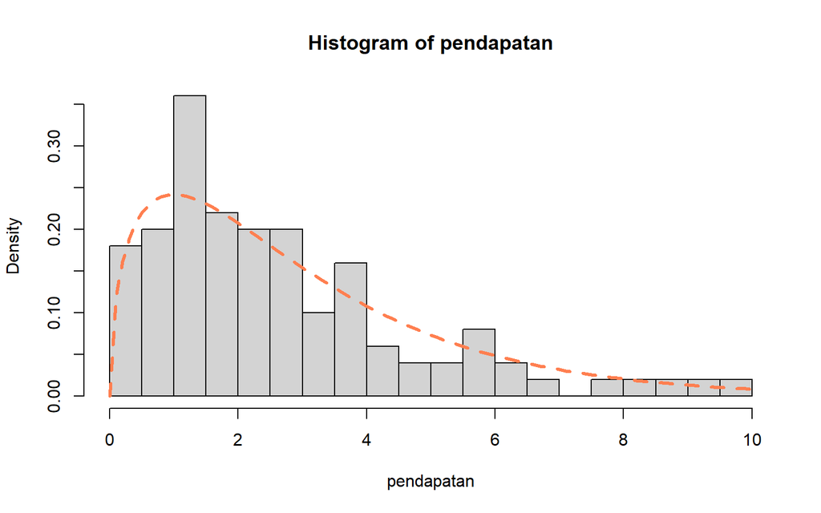

```r
hist(pendapatan, breaks=30, freq=F)
curve(dchisq(x, 3), lty=2, col="coral", lwd=3, add=T)
```

Cek Q-Q Plot

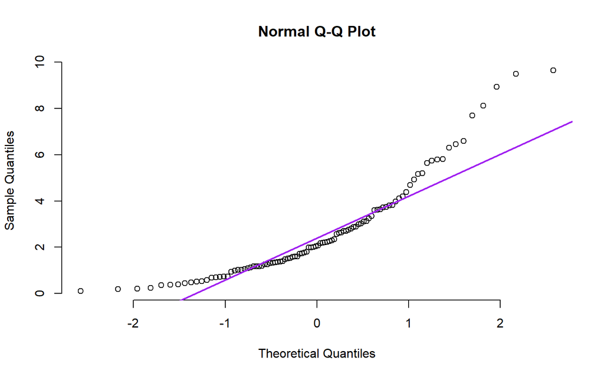

```r
qqnorm(x, pch=1, frame=F)
qqline(x, col="purple", lwd=2)
```

## Transformasi ln(X)

Dapat dicobakan transformasi ln(X) atau sqrt(X)

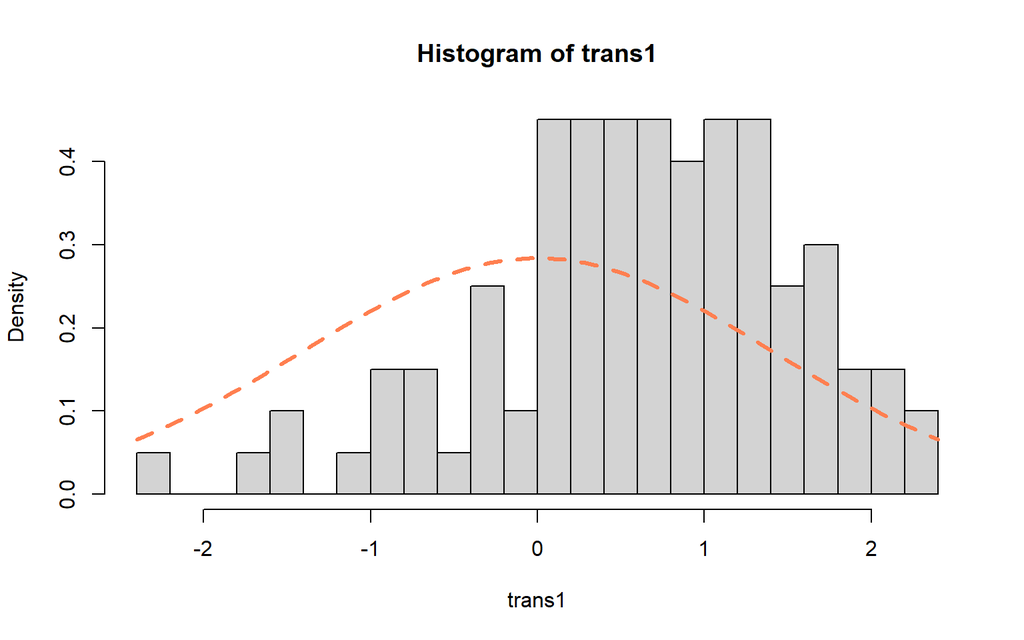

```r
trans1 <- log(pendapatan)
x <- trans1

hist(trans1, breaks=30, freq=F)
curve(dnorm(x, mean(x), sd(x)), lty=2, col="coral", lwd=3, add=T)
```

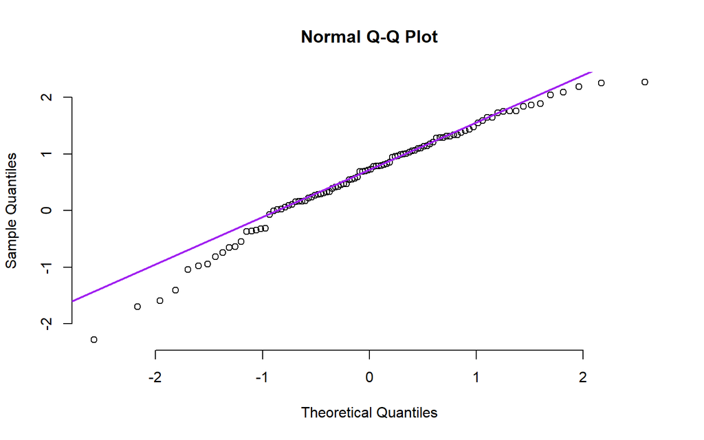

```r
qqnorm(x, pch=1, frame=F)
qqline(x, col="purple", lwd=2)
```

## Transformasi sqrt(X)

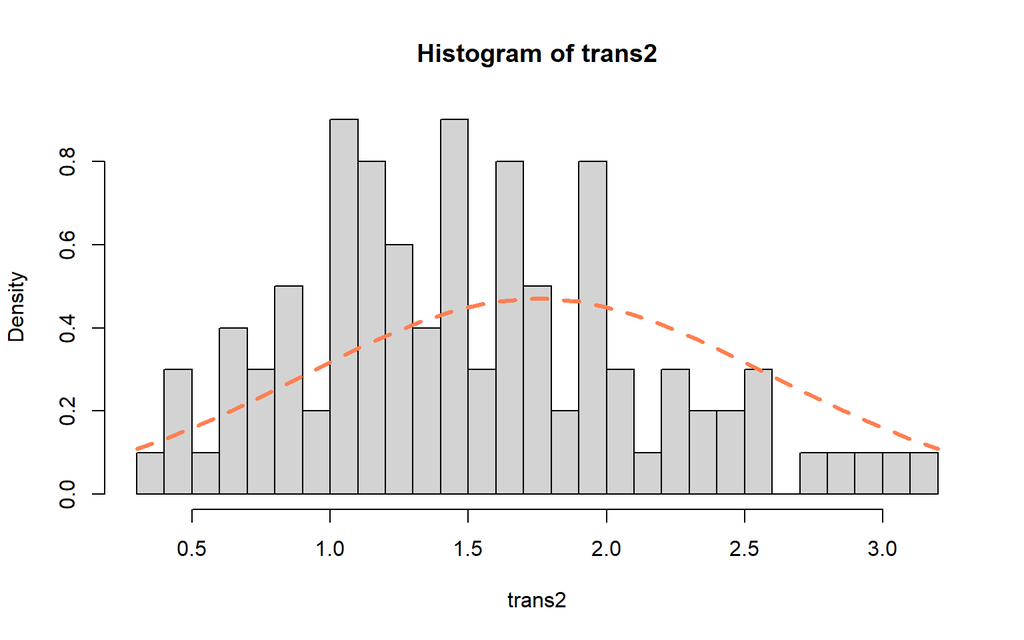

```r
trans2 <- sqrt(pendapatan)
x <- trans2

hist(trans2, breaks=30, freq=F)
curve(dnorm(x, mean(x), sd(x)), lty=2, col="coral", lwd=3, add=T)
```

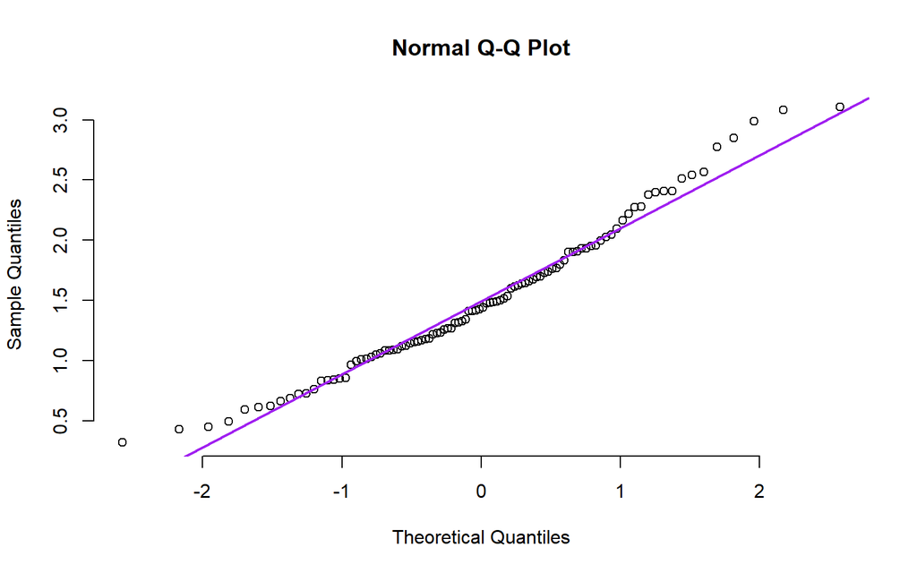

```r
qqnorm(x, pch=1, frame=F)
qqline(x, col="purple", lwd=2)
```

## Metode Box-Cox

```r
bb <- boxcox(lm(pendapatan~1))
```

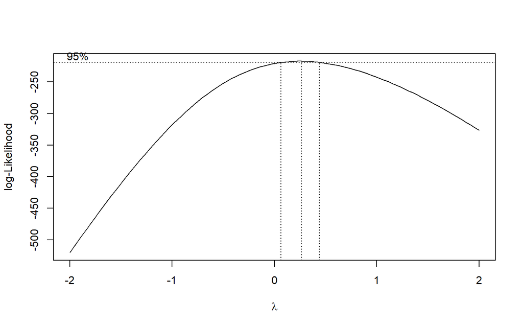

```r
lambda <- bb$x[which.max(bb$y)]
lambda
```

```
## [1] 0.2626263
```

Berdasarkan plot log-likelihood yang dihasilkan, nilai $\lambda$ optimal ditemukan sebesar 0.2626263. Nilai ini berada di antara 0 (transformasi logaritma) dan 0.5 (transformasi akar kuadrat), yang secara spesifik digunakan untuk menormalkan data yang memiliki kemiringan tertentu.

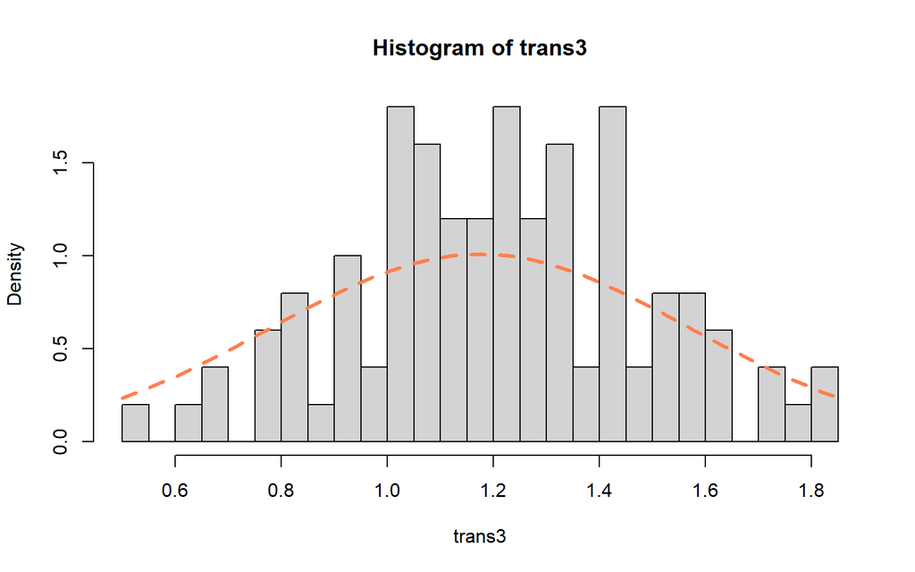

```r
trans3 <- pendapatan^(lambda)
x <- trans3

hist(trans3, breaks=30, freq=F)
curve(dnorm(x, mean(x), sd(x)), lty=2, col="coral", lwd=3, add=T)
```

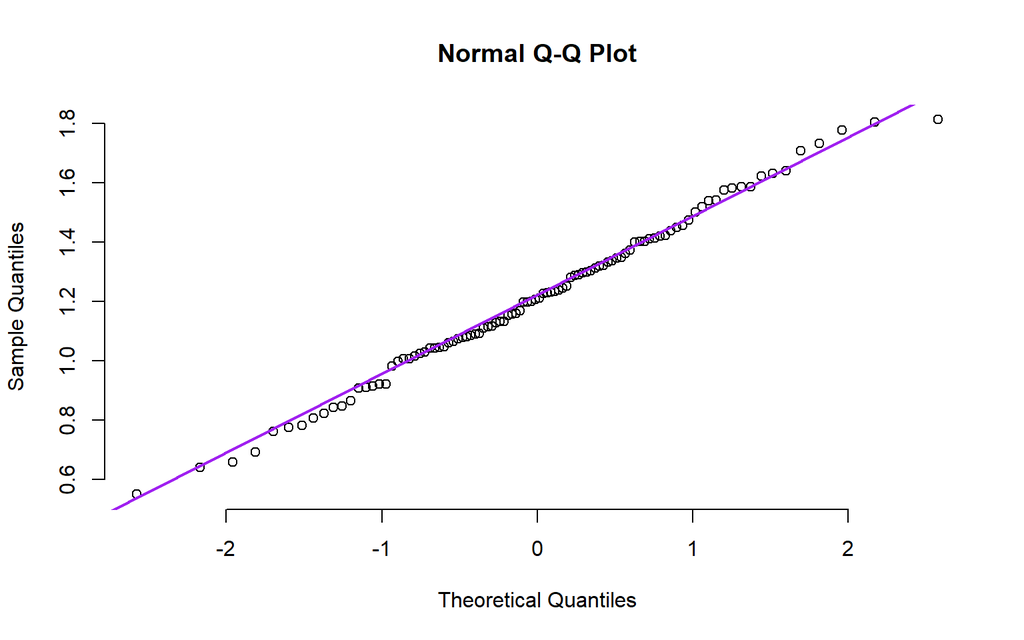

```r
qqnorm(x, pch=1, frame=F)
qqline(x, col="purple", lwd=2)
```

Setelah nilai $\lambda$ optimal diterapkan pada data, dilakukan evaluasi ulang terhadap bentuk sebaran data hasil transformasi:

- Histogram: Visualisasi menunjukkan bahwa sebaran data kini telah mengikuti kurva normal secara lebih presisi dibandingkan data asli. Distribusi data terlihat lebih simetris dan tidak lagi condong ke satu sisi.
- Normal Q-Q Plot: Titik-titik pengamatan pada plot Q-Q kini hampir seluruhnya berhimpit pada garis referensi diagonal. Hal ini membuktikan bahwa asumsi normalitas telah terpenuhi dengan baik pasca-transformasi.